# AmesHousing Modeling

Sindhuja Chinthala

Apr 3,2018

# 1 Data Cleansing

```r
library(tidyverse)
library(ggplot2)
library(MASS)
library(corrplot)
library(usdm)
library(glmnet)
library(pcr)
library(pls)
library(tree)
library(rapportools)
library(fastDummies)
library(broom)
library(randomForest)
library(e1071)

Train <- read.csv("C:/Users/sindh/Desktop/UCLA/FinalProject/train.csv", stringsAsFactors = FALSE,
    na.strings = c("", "NA"))
Test <- read.csv("C:/Users/sindh/Desktop/UCLA/FinalProject/test.csv", stringsAsFactors = FALSE,
    na.strings = c("", "NA"))

dim(Train)
```

```
## [1] 1460   81
```

```r
dim(Test)
```

```
## [1] 1459   80
```

```r
str(Train)
```

```
## 'data.frame':    1460 obs. of  81 variables:
##  $ Id           : int  1 2 3 4 5 6 7 8 9 10 ...
##  $ MSSubClass   : int  60 20 60 70 60 50 20 60 50 190 ...
##  $ MSZoning     : chr  "RL" "RL" "RL" "RL" ...
##  $ LotFrontage  : int  65 80 68 60 84 85 75 NA 51 50 ...
##  $ LotArea      : int  8450 9600 11250 9550 14260 14115 10084 10382 6120 7420 ...
##  $ Street       : chr  "Pave" "Pave" "Pave" "Pave" ...
##  $ Alley        : chr  NA NA NA NA ...
##  $ LotShape     : chr  "Reg" "Reg" "IR1" "IR1" ...
##  $ LandContour  : chr  "Lvl" "Lvl" "Lvl" "Lvl" ...
##  $ Utilities    : chr  "AllPub" "AllPub" "AllPub" "AllPub" ...
##  $ LotConfig    : chr  "Inside" "FR2" "Inside" "Corner" ...
##  $ LandSlope    : chr  "Gtl" "Gtl" "Gtl" "Gtl" ...
##  $ Neighborhood : chr  "CollgCr" "Veenker" "CollgCr" "Crawfor" ...
##  $ Condition1   : chr  "Norm" "Feedr" "Norm" "Norm" ...
```

[output cut: 67 more lines]

```r
str(Test)
```

```
## 'data.frame':    1459 obs. of  80 variables:
##  $ Id           : int  1461 1462 1463 1464 1465 1466 1467 1468 1469 1470 ...
##  $ MSSubClass   : int  20 20 60 60 120 60 20 60 20 20 ...
##  $ MSZoning     : chr  "RH" "RL" "RL" "RL" ...
##  $ LotFrontage  : int  80 81 74 78 43 75 NA 63 85 70 ...
##  $ LotArea      : int  11622 14267 13830 9978 5005 10000 7980 8402 10176 8400 ...
##  $ Street       : chr  "Pave" "Pave" "Pave" "Pave" ...
##  $ Alley        : chr  NA NA NA NA ...
##  $ LotShape     : chr  "Reg" "IR1" "IR1" "IR1" ...
##  $ LandContour  : chr  "Lvl" "Lvl" "Lvl" "Lvl" ...
##  $ Utilities    : chr  "AllPub" "AllPub" "AllPub" "AllPub" ...
##  $ LotConfig    : chr  "Inside" "Corner" "Inside" "Inside" ...
##  $ LandSlope    : chr  "Gtl" "Gtl" "Gtl" "Gtl" ...
##  $ Neighborhood : chr  "NAmes" "NAmes" "Gilbert" "Gilbert" ...
##  $ Condition1   : chr  "Feedr" "Norm" "Norm" "Norm" ...
```

[output cut: 66 more lines]

```r
str(Filter(is.numeric, Train))
```

```
## 'data.frame':    1460 obs. of  38 variables:
##  $ Id           : int  1 2 3 4 5 6 7 8 9 10 ...
##  $ MSSubClass   : int  60 20 60 70 60 50 20 60 50 190 ...
##  $ LotFrontage  : int  65 80 68 60 84 85 75 NA 51 50 ...
##  $ LotArea      : int  8450 9600 11250 9550 14260 14115 10084 10382 6120 7420 ...
##  $ OverallQual  : int  7 6 7 7 8 5 8 7 7 5 ...
##  $ OverallCond  : int  5 8 5 5 5 5 5 6 5 6 ...
##  $ YearBuilt    : int  2003 1976 2001 1915 2000 1993 2004 1973 1931 1939 ...
##  $ YearRemodAdd : int  2003 1976 2002 1970 2000 1995 2005 1973 1950 1950 ...
##  $ MasVnrArea   : int  196 0 162 0 350 0 186 240 0 0 ...
##  $ BsmtFinSF1   : int  706 978 486 216 655 732 1369 859 0 851 ...
##  $ BsmtFinSF2   : int  0 0 0 0 0 0 0 32 0 0 ...
##  $ BsmtUnfSF    : int  150 284 434 540 490 64 317 216 952 140 ...
##  $ TotalBsmtSF  : int  856 1262 920 756 1145 796 1686 1107 952 991 ...
##  $ X1stFlrSF    : int  856 1262 920 961 1145 796 1694 1107 1022 1077 ...
```

[output cut: 24 more lines]

```r
Test$Id <- NULL
Train$Id <- NULL
sum(is.na(Train))
```

```
## [1] 6965
```

```r
sum(is.empty(Train))
```

```
## [1] 24329
```

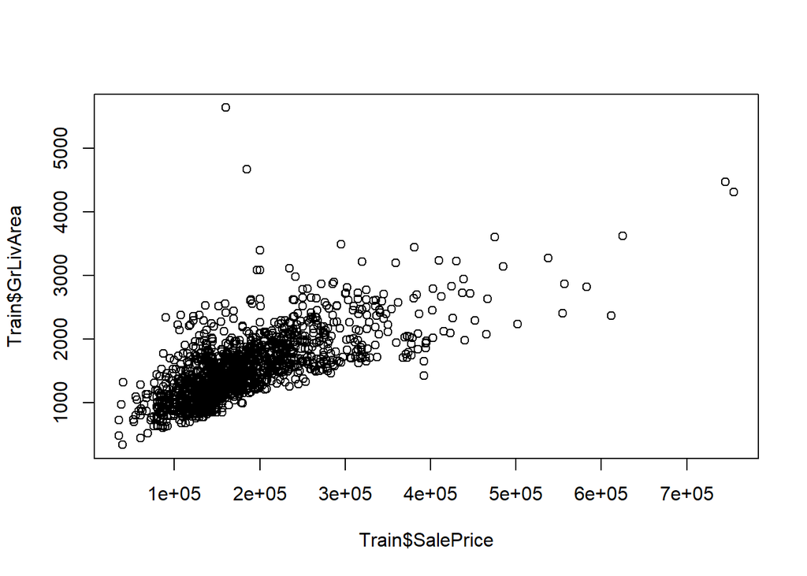

```r
plot(Train$SalePrice, Train$GrLivArea)
```

```r
sorted <- Train[order(Train$GrLivArea, decreasing = TRUE), ]
head(sorted)
```

```
##      MSSubClass MSZoning LotFrontage LotArea Street Alley LotShape
## 1299         60       RL         313   63887   Pave  <NA>      IR3
## 524          60       RL         130   40094   Pave  <NA>      IR1
## 1183         60       RL         160   15623   Pave  <NA>      IR1
## 692          60       RL         104   21535   Pave  <NA>      IR1
## 1170         60       RL         118   35760   Pave  <NA>      IR1
## 186          75       RM          90   22950   Pave  <NA>      IR2
##      LandContour Utilities LotConfig LandSlope Neighborhood Condition1
## 1299         Bnk    AllPub    Corner       Gtl      Edwards      Feedr
## 524          Bnk    AllPub    Inside       Gtl      Edwards       PosN
## 1183         Lvl    AllPub    Corner       Gtl      NoRidge       Norm
## 692          Lvl    AllPub    Corner       Gtl      NoRidge       Norm
## 1170         Lvl    AllPub   CulDSac       Gtl      NoRidge       Norm
## 186          Lvl    AllPub    Inside       Gtl      OldTown     Artery
##      Condition2 BldgType HouseStyle OverallQual OverallCond YearBuilt
```

[output cut: 83 more lines]

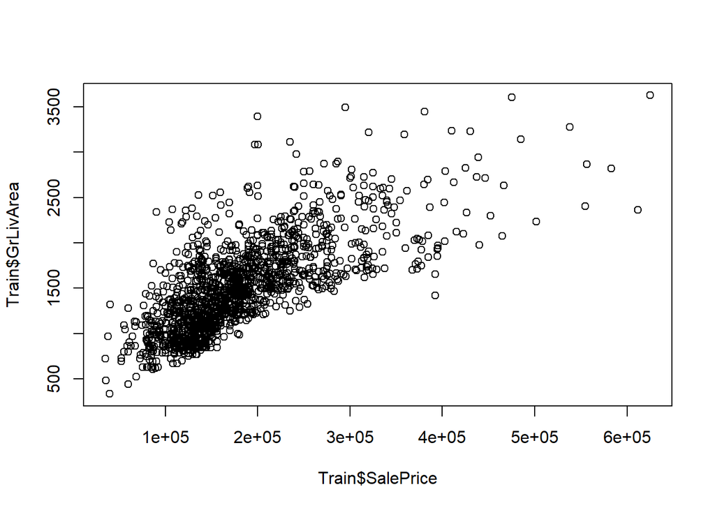

```r
Train <- Train[-c(1299, 524, 1183, 692), ]
plot(Train$SalePrice, Train$GrLivArea)
```

```r
nan_sums <- colSums(is.na(Train))
nan_sums[nan_sums > 0]
```

```
##  LotFrontage        Alley   MasVnrType   MasVnrArea     BsmtQual
##          259         1365            8            8           37
##     BsmtCond BsmtExposure BsmtFinType1 BsmtFinType2   Electrical
##           37           38           37           38            1
##  FireplaceQu   GarageType  GarageYrBlt GarageFinish   GarageQual
##          690           81           81           81           81
##   GarageCond       PoolQC        Fence  MiscFeature
##           81         1451         1176         1402
```

```r
summary(Train)
```

```
##    MSSubClass       MSZoning          LotFrontage        LotArea
##  Min.   : 20.00   Length:1456        Min.   : 21.00   Min.   :  1300
##  1st Qu.: 20.00   Class :character   1st Qu.: 59.00   1st Qu.:  7539
##  Median : 50.00   Mode  :character   Median : 69.00   Median :  9468
##  Mean   : 56.89                      Mean   : 69.69   Mean   : 10449
##  3rd Qu.: 70.00                      3rd Qu.: 80.00   3rd Qu.: 11588
##  Max.   :190.00                      Max.   :313.00   Max.   :215245
##                                      NA's   :259
##     Street             Alley             LotShape
##  Length:1456        Length:1456        Length:1456
##  Class :character   Class :character   Class :character
##  Mode  :character   Mode  :character   Mode  :character
##
##
##
##
##  LandContour         Utilities          LotConfig
##  Length:1456        Length:1456        Length:1456
##  Class :character   Class :character   Class :character
##  Mode  :character   Mode  :character   Mode  :character
##
##
##
##
##   LandSlope         Neighborhood        Condition1
##  Length:1456        Length:1456        Length:1456
##  Class :character   Class :character   Class :character
##  Mode  :character   Mode  :character   Mode  :character
##
##
##
##
##   Condition2          BldgType          HouseStyle         OverallQual
##  Length:1456        Length:1456        Length:1456        Min.   : 1.000
##  Class :character   Class :character   Class :character   1st Qu.: 5.000
##  Mode  :character   Mode  :character   Mode  :character   Median : 6.000
##                                                           Mean   : 6.089
##                                                           3rd Qu.: 7.000
##                                                           Max.   :10.000
##
```

[output cut: 121 more lines]

```
##  Min.   :    0.00   Min.   : 1.000   Min.   :2006   Length:1456
##  1st Qu.:    0.00   1st Qu.: 5.000   1st Qu.:2007   Class :character
##  Median :    0.00   Median : 6.000   Median :2008   Mode  :character
##  Mean   :   43.61   Mean   : 6.326   Mean   :2008
##  3rd Qu.:    0.00   3rd Qu.: 8.000   3rd Qu.:2009
##  Max.   :15500.00   Max.   :12.000   Max.   :2010
##
##  SaleCondition        SalePrice
##  Length:1456        Min.   : 34900
##  Class :character   1st Qu.:129900
##  Mode  :character   Median :163000
##                     Mean   :180151
##                     3rd Qu.:214000
##                     Max.   :625000
##
```

```r
str(Train)
```

```
## 'data.frame':    1456 obs. of  80 variables:
##  $ MSSubClass   : int  60 20 60 70 60 50 20 60 50 190 ...
##  $ MSZoning     : chr  "RL" "RL" "RL" "RL" ...
##  $ LotFrontage  : int  65 80 68 60 84 85 75 NA 51 50 ...
##  $ LotArea      : int  8450 9600 11250 9550 14260 14115 10084 10382 6120 7420 ...
##  $ Street       : chr  "Pave" "Pave" "Pave" "Pave" ...
##  $ Alley        : chr  NA NA NA NA ...
##  $ LotShape     : chr  "Reg" "Reg" "IR1" "IR1" ...
##  $ LandContour  : chr  "Lvl" "Lvl" "Lvl" "Lvl" ...
##  $ Utilities    : chr  "AllPub" "AllPub" "AllPub" "AllPub" ...
##  $ LotConfig    : chr  "Inside" "FR2" "Inside" "Corner" ...
##  $ LandSlope    : chr  "Gtl" "Gtl" "Gtl" "Gtl" ...
##  $ Neighborhood : chr  "CollgCr" "Veenker" "CollgCr" "Crawfor" ...
##  $ Condition1   : chr  "Norm" "Feedr" "Norm" "Norm" ...
##  $ Condition2   : chr  "Norm" "Norm" "Norm" "Norm" ...
```

[output cut: 66 more lines]

```r
Train$MSSubClass <- as.factor(Train$MSSubClass)
Train$OverallQual <- as.factor(Train$OverallQual)
Train$OverallCond <- as.factor(Train$OverallCond)
Train$BsmtFullBath <- as.factor(Train$BsmtFullBath)
Train$BsmtHalfBath <- as.factor(Train$BsmtHalfBath)
Train$FullBath <- as.factor(Train$FullBath)
Train$HalfBath <- as.factor(Train$HalfBath)
Train$BedroomAbvGr <- as.factor(Train$BedroomAbvGr)
Train$KitchenAbvGr <- as.factor(Train$KitchenAbvGr)
Train$TotRmsAbvGrd <- as.factor(Train$TotRmsAbvGrd)
Train$Fireplaces <- as.factor(Train$Fireplaces)
Train$GarageCars <- as.factor(Train$GarageCars)
Train$MoSold <- as.factor(Train$MoSold)

str(Train)
```

```
## 'data.frame':    1456 obs. of  80 variables:
##  $ MSSubClass   : Factor w/ 15 levels "20","30","40",..: 6 1 6 7 6 5 1 6 5 15 ...
##  $ MSZoning     : chr  "RL" "RL" "RL" "RL" ...
##  $ LotFrontage  : int  65 80 68 60 84 85 75 NA 51 50 ...
##  $ LotArea      : int  8450 9600 11250 9550 14260 14115 10084 10382 6120 7420 ...
##  $ Street       : chr  "Pave" "Pave" "Pave" "Pave" ...
##  $ Alley        : chr  NA NA NA NA ...
##  $ LotShape     : chr  "Reg" "Reg" "IR1" "IR1" ...
##  $ LandContour  : chr  "Lvl" "Lvl" "Lvl" "Lvl" ...
##  $ Utilities    : chr  "AllPub" "AllPub" "AllPub" "AllPub" ...
##  $ LotConfig    : chr  "Inside" "FR2" "Inside" "Corner" ...
##  $ LandSlope    : chr  "Gtl" "Gtl" "Gtl" "Gtl" ...
##  $ Neighborhood : chr  "CollgCr" "Veenker" "CollgCr" "Crawfor" ...
##  $ Condition1   : chr  "Norm" "Feedr" "Norm" "Norm" ...
##  $ Condition2   : chr  "Norm" "Norm" "Norm" "Norm" ...
```

[output cut: 66 more lines]

```r
match(c("Alley", "PoolArea", "PoolQC", "Fence", "MiscFeature"), names(Train))
```

```
## [1]  6 71 72 73 74
```

```r
Train <- Train[, -c(6, 71:74)]
dim(Train)
```

```
## [1] 1456   75
```

```r
meanLotFrontage <- mean(Train$LotFrontage, na.rm = TRUE)
meanMasVnrArea <- mean(Train$MasVnrArea, na.rm = TRUE)
meanBsmtFinSF1 <- mean(Train$BsmtFinSF1, na.rm = TRUE)
meanBsmtFinSF2 <- mean(Train$BsmtFinSF2, na.rm = TRUE)
meanBsmtUnfSF <- mean(Train$BsmtUnfSF, na.rm = TRUE)
meanTotalBsmtSF <- mean(Train$TotalBsmtSF, na.rm = TRUE)
meanGarageYrBlt <- mean(Train$GarageYrBlt, na.rm = TRUE)
meanGarageArea <- mean(Train$GarageArea, na.rm = TRUE)

Train$LotFrontage[is.na(Train$LotFrontage)] <- meanLotFrontage
Train$MasVnrArea[is.na(Train$MasVnrArea)] <- meanMasVnrArea
Train$BsmtFinSF1[is.na(Train$BsmtFinSF1)] <- meanBsmtFinSF1
Train$BsmtFinSF2[is.na(Train$BsmtFinSF2)] <- meanBsmtFinSF2
Train$BsmtUnfSF[is.na(Train$BsmtUnfSF)] <- meanBsmtUnfSF
Train$TotalBsmtSF[is.na(Train$TotalBsmtSF)] <- meanTotalBsmtSF
Train$GarageYrBlt[is.na(Train$GarageYrBlt)] <- meanGarageYrBlt
Train$GarageArea[is.na(Train$GarageArea)] <- meanGarageArea

sum(is.na(Train))
```

```
## [1] 1210
```

```r
Train$BsmtFullBath <- as.character(Train$BsmtFullBath)
Train$BsmtHalfBath <- as.character(Train$BsmtHalfBath)
Train$GarageCars <- as.character(Train$GarageCars)

Train$BsmtQual[is.na(Train$BsmtQual)] <- "w/o"
Train$BsmtCond[is.na(Train$BsmtCond)] <- "w/o"
Train$BsmtExposure[is.na(Train$BsmtExposure)] <- "w/o"
Train$BsmtFinType1[is.na(Train$BsmtFinType1)] <- "w/o"
Train$BsmtFinType2[is.na(Train$BsmtFinType2)] <- "w/o"
Train$BsmtFullBath[is.na(Train$BsmtFullBath)] <- "w/o"
Train$BsmtHalfBath[is.na(Train$BsmtHalfBath)] <- "w/o"
Train$FireplaceQu[is.na(Train$FireplaceQu)] <- "w/o"
Train$GarageType[is.na(Train$GarageType)] <- "w/o"
Train$GarageFinish[is.na(Train$GarageFinish)] <- "w/o"
Train$GarageCars[is.na(Train$GarageCars)] <- "w/o"
Train$GarageQual[is.na(Train$GarageQual)] <- "w/o"
Train$GarageCond[is.na(Train$GarageCond)] <- "w/o"

sum(is.na(Train))
```

```
## [1] 9
```

```r
nan_sums <- colSums(is.na(Train))
nan_sums[nan_sums > 0]
```

```
## MasVnrType Electrical
##          8          1
```

```r
sum(is.empty(Train$Electrical))
```

```
## [1] 1
```

```r
sum(is.empty(Train$MasVnrType))
```

```
## [1] 8
```

```r
Train$MasVnrType[is.na(Train$MasVnrType)] <- "None"
Train$Electrical[is.na(Train$Electrical)] <- "SBrkr"
sum(is.na(Train))
```

```
## [1] 0
```

```r
sum(is.empty(Train))
```

```
## [1] 11952
```

```r
Train <- as.data.frame(unclass(Train))
str(Train)
```

```
## 'data.frame':    1456 obs. of  75 variables:
##  $ MSSubClass   : Factor w/ 15 levels "20","30","40",..: 6 1 6 7 6 5 1 6 5 15 ...
##  $ MSZoning     : Factor w/ 5 levels "C (all)","FV",..: 4 4 4 4 4 4 4 4 5 4 ...
##  $ LotFrontage  : num  65 80 68 60 84 ...
##  $ LotArea      : int  8450 9600 11250 9550 14260 14115 10084 10382 6120 7420 ...
##  $ Street       : Factor w/ 2 levels "Grvl","Pave": 2 2 2 2 2 2 2 2 2 2 ...
##  $ LotShape     : Factor w/ 4 levels "IR1","IR2","IR3",..: 4 4 1 1 1 1 4 1 4 4 ...
##  $ LandContour  : Factor w/ 4 levels "Bnk","HLS","Low",..: 4 4 4 4 4 4 4 4 4 4 ...
##  $ Utilities    : Factor w/ 2 levels "AllPub","NoSeWa": 1 1 1 1 1 1 1 1 1 1 ...
##  $ LotConfig    : Factor w/ 5 levels "Corner","CulDSac",..: 5 3 5 1 3 5 5 1 5 1 ...
##  $ LandSlope    : Factor w/ 3 levels "Gtl","Mod","Sev": 1 1 1 1 1 1 1 1 1 1 ...
##  $ Neighborhood : Factor w/ 25 levels "Blmngtn","Blueste",..: 6 25 6 7 14 12 21 17 18 4 ...
##  $ Condition1   : Factor w/ 9 levels "Artery","Feedr",..: 3 2 3 3 3 3 3 5 1 1 ...
##  $ Condition2   : Factor w/ 8 levels "Artery","Feedr",..: 3 3 3 3 3 3 3 3 3 1 ...
##  $ BldgType     : Factor w/ 5 levels "1Fam","2fmCon",..: 1 1 1 1 1 1 1 1 1 2 ...
```

[output cut: 61 more lines]

To check for the collinearity between the features by visualizing the data.

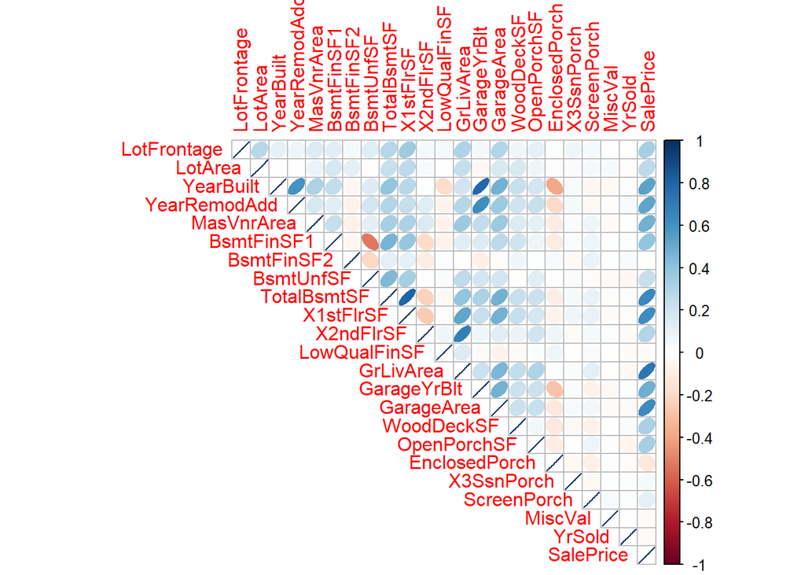

```r
corNum <- cor(Filter(is.numeric, Train))
corrplot::corrplot(corNum, type = "upper", method = "ellipse")
```

# 2 Handling Categorical features

```r
TrTibble <- as_tibble(Train)
TrTibble
```

```
## # A tibble: 1,456 x 75
##    MSSubClass MSZoning LotFrontage LotArea Street LotShape LandContour
##    <fct>      <fct>          <dbl>   <int> <fct>  <fct>    <fct>
##  1 60         RL              65.0    8450 Pave   Reg      Lvl
##  2 20         RL              80.0    9600 Pave   Reg      Lvl
##  3 60         RL              68.0   11250 Pave   IR1      Lvl
##  4 70         RL              60.0    9550 Pave   IR1      Lvl
##  5 60         RL              84.0   14260 Pave   IR1      Lvl
##  6 50         RL              85.0   14115 Pave   IR1      Lvl
##  7 20         RL              75.0   10084 Pave   Reg      Lvl
##  8 60         RL              69.7   10382 Pave   IR1      Lvl
##  9 50         RM              51.0    6120 Pave   Reg      Lvl
## 10 190        RL              50.0    7420 Pave   Reg      Lvl
## # ... with 1,446 more rows, and 68 more variables: Utilities <fct>,
## #   LotConfig <fct>, LandSlope <fct>, Neighborhood <fct>,
## #   Condition1 <fct>, Condition2 <fct>, BldgType <fct>, HouseStyle <fct>,
## #   OverallQual <fct>, OverallCond <fct>, YearBuilt <int>,
## #   YearRemodAdd <int>, RoofStyle <fct>, RoofMatl <fct>,
## #   Exterior1st <fct>, Exterior2nd <fct>, MasVnrType <fct>,
## #   MasVnrArea <dbl>, ExterQual <fct>, ExterCond <fct>, Foundation <fct>,
## #   BsmtQual <fct>, BsmtCond <fct>, BsmtExposure <fct>,
## #   BsmtFinType1 <fct>, BsmtFinSF1 <dbl>, BsmtFinType2 <fct>,
## #   BsmtFinSF2 <dbl>, BsmtUnfSF <dbl>, TotalBsmtSF <dbl>, Heating <fct>,
## #   HeatingQC <fct>, CentralAir <fct>, Electrical <fct>, X1stFlrSF <int>,
## #   X2ndFlrSF <int>, LowQualFinSF <int>, GrLivArea <int>,
## #   BsmtFullBath <fct>, BsmtHalfBath <fct>, FullBath <fct>,
## #   HalfBath <fct>, BedroomAbvGr <fct>, KitchenAbvGr <fct>,
## #   KitchenQual <fct>, TotRmsAbvGrd <fct>, Functional <fct>,
## #   Fireplaces <fct>, FireplaceQu <fct>, GarageType <fct>,
## #   GarageYrBlt <dbl>, GarageFinish <fct>, GarageCars <fct>,
## #   GarageArea <dbl>, GarageQual <fct>, GarageCond <fct>,
## #   PavedDrive <fct>, WoodDeckSF <int>, OpenPorchSF <int>,
## #   EnclosedPorch <int>, X3SsnPorch <int>, ScreenPorch <int>,
## #   MiscVal <int>, MoSold <fct>, YrSold <int>, SaleType <fct>,
## #   SaleCondition <fct>, SalePrice <int>
```

```r
TrDummy <- dummy_cols(TrTibble, remove_first_dummy = TRUE)
str(TrDummy)
```

```
## Classes 'tbl_df', 'tbl' and 'data.frame':    1456 obs. of  364 variables:
##  $ MSSubClass           : Factor w/ 15 levels "20","30","40",..: 6 1 6 7 6 5 1 6 5 15 ...
##  $ MSZoning             : Factor w/ 5 levels "C (all)","FV",..: 4 4 4 4 4 4 4 4 5 4 ...
##  $ LotFrontage          : num  65 80 68 60 84 ...
##  $ LotArea              : int  8450 9600 11250 9550 14260 14115 10084 10382 6120 7420 ...
##  $ Street               : Factor w/ 2 levels "Grvl","Pave": 2 2 2 2 2 2 2 2 2 2 ...
##  $ LotShape             : Factor w/ 4 levels "IR1","IR2","IR3",..: 4 4 1 1 1 1 4 1 4 4 ...
##  $ LandContour          : Factor w/ 4 levels "Bnk","HLS","Low",..: 4 4 4 4 4 4 4 4 4 4 ...
##  $ Utilities            : Factor w/ 2 levels "AllPub","NoSeWa": 1 1 1 1 1 1 1 1 1 1 ...
##  $ LotConfig            : Factor w/ 5 levels "Corner","CulDSac",..: 5 3 5 1 3 5 5 1 5 1 ...
##  $ LandSlope            : Factor w/ 3 levels "Gtl","Mod","Sev": 1 1 1 1 1 1 1 1 1 1 ...
##  $ Neighborhood         : Factor w/ 25 levels "Blmngtn","Blueste",..: 6 25 6 7 14 12 21 17 18 4 ...
##  $ Condition1           : Factor w/ 9 levels "Artery","Feedr",..: 3 2 3 3 3 3 3 5 1 1 ...
##  $ Condition2           : Factor w/ 8 levels "Artery","Feedr",..: 3 3 3 3 3 3 3 3 3 1 ...
##  $ BldgType             : Factor w/ 5 levels "1Fam","2fmCon",..: 1 1 1 1 1 1 1 1 1 2 ...
```

[output cut: 87 more lines]

```r
match(c("SalePrice"), names(TrDummy))
```

```
## [1] 75
```

```r
TrDumNoTg <- TrDummy[, -75]
TrTarget <- TrDummy[, 75]
names(Filter(is.factor, TrDumNoTg))
```

```
##  [1] "MSSubClass"    "MSZoning"      "Street"        "LotShape"
##  [5] "LandContour"   "Utilities"     "LotConfig"     "LandSlope"
##  [9] "Neighborhood"  "Condition1"    "Condition2"    "BldgType"
## [13] "HouseStyle"    "OverallQual"   "OverallCond"   "RoofStyle"
## [17] "RoofMatl"      "Exterior1st"   "Exterior2nd"   "MasVnrType"
## [21] "ExterQual"     "ExterCond"     "Foundation"    "BsmtQual"
## [25] "BsmtCond"      "BsmtExposure"  "BsmtFinType1"  "BsmtFinType2"
## [29] "Heating"       "HeatingQC"     "CentralAir"    "Electrical"
## [33] "BsmtFullBath"  "BsmtHalfBath"  "FullBath"      "HalfBath"
## [37] "BedroomAbvGr"  "KitchenAbvGr"  "KitchenQual"   "TotRmsAbvGrd"
## [41] "Functional"    "Fireplaces"    "FireplaceQu"   "GarageType"
## [45] "GarageFinish"  "GarageCars"    "GarageQual"    "GarageCond"
## [49] "PavedDrive"    "MoSold"        "SaleType"      "SaleCondition"
```

```r
dropCols <- c("MSSubClass", "MSZoning", "Street", "LotShape", "LandContour",
    "Utilities", "LotConfig", "LandSlope", "Neighborhood", "Condition1", "Condition2",
    "BldgType", "HouseStyle", "OverallQual", "OverallCond", "RoofStyle", "RoofMatl",
    "Exterior1st", "Exterior2nd", "MasVnrType", "ExterQual", "ExterCond", "Foundation",
    "BsmtQual", "BsmtCond", "BsmtExposure", "BsmtFinType1", "BsmtFinType2",
    "Heating", "HeatingQC", "CentralAir", "Electrical", "BsmtFullBath", "BsmtHalfBath",
    "FullBath", "HalfBath", "BedroomAbvGr", "KitchenAbvGr", "KitchenQual", "TotRmsAbvGrd",
    "Functional", "Fireplaces", "FireplaceQu", "GarageType", "GarageFinish",
    "GarageCars", "GarageQual", "GarageCond", "PavedDrive", "MoSold", "SaleType",
    "SaleCondition")
TrDumNoTg <- TrDumNoTg %>% dplyr::select(-one_of(dropCols))
TrDumwTg <- cbind(TrTarget, TrDumNoTg)
```

```r
dim(TrDumNoTg)
```

```
## [1] 1456  311
```

```r
dim(TrDumwTg)
```

```
## [1] 1456  312
```

```r
TrDumScale <- scale(TrDumNoTg, center = TRUE, scale = TRUE)
TrDumScaleDF <- as.tibble(TrDumScale)
TrDumScaleDF <- cbind(TrTarget, TrDumScaleDF)
```

# 3 Multilinear Regression

Feature Selection by building Benchmark model.

```r
lmRating <- lm(SalePrice ~ ., TrDumScaleDF)
lmCoefs <- tidy(lmRating)
lmCoefs$abs_est <- sqrt(lmCoefs$estimate^2)
lmCoefsAbs <- lmCoefs[-c(2:5)]
lmCoefsAbs <- lmCoefsAbs[-1, ]
head(lmCoefsAbs[order(-lmCoefsAbs$abs_est), ], 25)
```

```
##                     term   abs_est
## 11             X2ndFlrSF 22690.904
## 10             X1stFlrSF 19417.630
## 7             BsmtFinSF1 16769.149
## 4              YearBuilt 11395.548
## 9              BsmtUnfSF  8495.873
## 3                LotArea  8122.952
## 106        OverallQual_9  7417.176
## 108       OverallQual_10  6241.532
## 286         SaleType_New  5831.363
## 176       `BsmtQual_w/o`  5281.748
## 71  Neighborhood_StoneBr  4950.173
## 181      BsmtExposure_Gd  4592.937
## 55  Neighborhood_Crawfor  4590.131
## 8             BsmtFinSF2  4518.652
## 267        GarageQual_Ex  4517.044
## 104        OverallQual_8  4497.762
## 32        MSSubClass_160  4435.081
## 114        OverallCond_7  4144.061
## 53         LandSlope_Sev  4123.964
## 262         GarageCars_3  3884.179
## 105        OverallQual_5  3874.150
## 63  Neighborhood_NridgHt  3842.697
## 92       Condition2_RRAe  3651.160
## 247         Fireplaces_1  3636.425
## 124       RoofStyle_Shed  3464.105
```

We use Regression to determine which features are important for modeling.We split the data into Train and Test on the column id.The RMSE metric for multi linear regression model is pretty high and therefore we use different modeling techniques for better RMSE.

```r
TrDumwTg$id <- 1:nrow(TrDumwTg)
lmi.train <- TrDumwTg %>% sample_frac(0.5)
lmi.test <- anti_join(TrDumwTg, lmi.train, by = "id")
dim(lmi.test)
```

```
## [1] 728 313
```

```r
lmi.fit <- lm(SalePrice ~ ., data = lmi.train)
lmi.pred <- predict.lm(lmi.fit, newdata = lmi.test, scale = NULL)
mean((lmi.pred - lmi.test)^2)
```

```
## [1] 37720953875
```

```r
lmi.RMSE <- sqrt(mean((lmi.pred - lmi.test)^2))
lmi.RMSE
```

```
## [1] 194218.8
```

Since we identified ,there is collinearity between the features we dont have to include all the features.We select only GrLivArea and TotalBsmtSF to represent square footage and basement features.

```r
match(c("SalePrice", "GrLivArea", "TotalBsmtSF", "RoofMatl_ClyTile", "YearBuilt",
    "Condition2_PosN", "OverallQual_10", "SaleType_New", "Neighborhood_StoneBr",
    "LotArea", "Neighborhood_NridgHt", "GarageArea", "HouseStyle_1Story", "Neighborhood_Crawfor",
    "KitchenQual_Ex", "Neighborhood_NoRidge", "Fireplaces_2"), names(TrDumScaleDF))
```

```
##  [1]   1  14  10  NA   4  92 111 300  73   3  65  16  99  57 237  58 257
```

```r
Trfeatures <- TrDumScaleDF[, c(1, 14, 10, 4, 92, 111, 300, 73, 3, 65, 16, 99,
    57, 237, 58, 257)]
Trfeatures$id <- 1:nrow(Trfeatures)
lm.train <- Trfeatures %>% sample_frac(0.5)
lm.test <- anti_join(Trfeatures, lm.train, by = "id")
```

# 4 Ridge Regression

To improve the performance of the Linear Regression model we begin with other algorithms and we start with Ridge Regression Analysis.

```r
x = model.matrix(SalePrice ~ ., Trfeatures)[, -1]
y = Trfeatures$SalePrice
grid <- 10^seq(10, -2, length = 100)
ridge.mod = glmnet(x, y, alpha = 0, lambda = grid, standardize = FALSE)
ridge.mod
```

```
##
## Call:  glmnet(x = x, y = y, alpha = 0, lambda = grid, standardize = FALSE)
##
##        Df      %Dev    Lambda
##   [1,] 16 0.0006572 1.000e+10
##   [2,] 16 0.0007090 7.565e+09
##   [3,] 16 0.0007560 5.722e+09
##   [4,] 16 0.0008003 4.329e+09
##   [5,] 16 0.0008450 3.275e+09
##   [6,] 16 0.0008940 2.477e+09
##   [7,] 16 0.0009517 1.874e+09
##   [8,] 16 0.0010230 1.417e+09
##   [9,] 16 0.0011150 1.072e+09
##  [10,] 16 0.0012340 8.111e+08
##  [11,] 16 0.0013900 6.136e+08
```

[output cut: 89 more lines]

The Ridge Regression model creates a 17 X 100 matrix of values for model coefficients.Here we take a random lamba value at 50th position in the grid and calculate the coefficients with the lambda.We can calculate the RMSE for the ridge at that particular lambda which is a higher value.We can calculate the RMSE with some lambda values and check for the better RMSE.

```r
dim(coef(ridge.mod))
```

```
## [1]  17 100
```

```r
ridge.mod$lambda[50]
```

```
## [1] 11497.57
```

```r
coef(ridge.mod)[, 50]
```

```
##          (Intercept)            GrLivArea          TotalBsmtSF
##        181548.864468         24527.724204         14302.163237
##            YearBuilt      Condition2_PosN       OverallQual_10
##         16287.398082         -1794.506651          7257.623236
##         SaleType_New Neighborhood_StoneBr              LotArea
##          6722.570262          6644.562058          6419.469935
## Neighborhood_NridgHt           GarageArea    HouseStyle_1Story
##          7013.963859         10620.629573         -2602.780873
## Neighborhood_Crawfor       KitchenQual_Ex Neighborhood_NoRidge
##          6290.774272         10935.060148          7245.844694
##         Fireplaces_2                   id
##          3720.227606            -1.918505
```

```r
sqrt(sum(coef(ridge.mod)[-1, 50]^2))
```

```
## [1] 40646.6
```

Here we select the best lambda value for the model and calculate the RMSE.

```r
set.seed(705)
train = sample(1:nrow(x), nrow(x)/2)
test = (-train)
y.test = y[test]
ridge.mod <- glmnet(x[train, ], y[train], alpha = 0, lambda = grid, thresh = 1e-12)
ridge.pred <- predict(ridge.mod, s = 4, newx = x[test, ])
mean((ridge.pred - y.test)^2)
```

```
## [1] 862385441
```

```r
ridge.RMSE <- sqrt(mean((ridge.pred - y.test)^2))
ridge.RMSE
```

```
## [1] 29366.4
```

Also we can tune the model parameters by using Cross Validation.We get best lambda value as 6218.8 which yields an RMSE of 29425.1.The below plot shows where the lambda values lies.

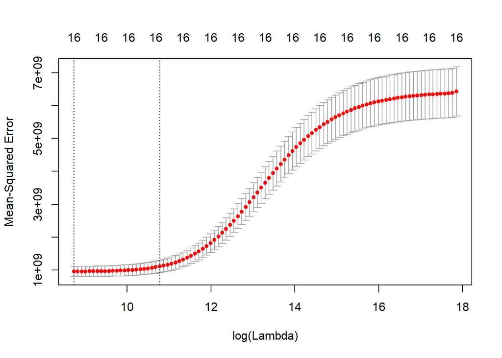

```r
set.seed(705)
cv.out <- cv.glmnet(x[train, ], y[train], alpha = 0)
plot(cv.out)
```

```r
bestlam <- cv.out$lambda.min
bestlam
```

```
## [1] 6218.845
```

```r
ridge.pred <- predict(ridge.mod, s = bestlam, newx = x[test, ])
mean((ridge.pred - y.test)^2)
```

```
## [1] 865836417
```

```r
bestridge.RMSE <- sqrt(mean((ridge.pred - y.test)^2))
bestridge.RMSE
```

```
## [1] 29425.1
```

```r
out <- glmnet(x, y, alpha = 0)
predict(out, type = "coefficients", s = bestlam)[1:16, ]
```

```
##          (Intercept)            GrLivArea          TotalBsmtSF
##           181418.328            26117.261            14257.583
##            YearBuilt      Condition2_PosN       OverallQual_10
##            17249.951            -2011.911             7467.318
##         SaleType_New Neighborhood_StoneBr              LotArea
##             6685.539             6816.288             6556.418
## Neighborhood_NridgHt           GarageArea    HouseStyle_1Story
##             6984.071            10142.221            -2257.202
## Neighborhood_Crawfor       KitchenQual_Ex Neighborhood_NoRidge
##             6709.299            11163.857             7257.337
##         Fireplaces_2
##             3621.784
```

# 5 Lasso Regression

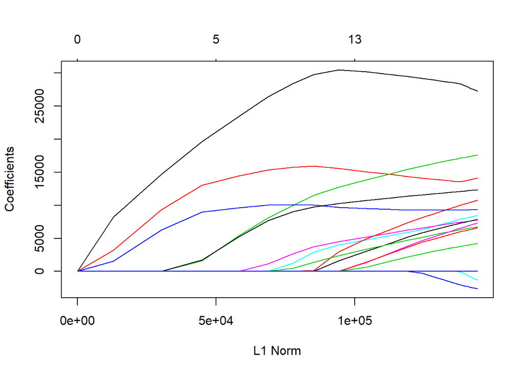

```r
lasso.mod <- glmnet(x[train, ], y[train], alpha = 1, lambda = grid)
plot(lasso.mod)
```

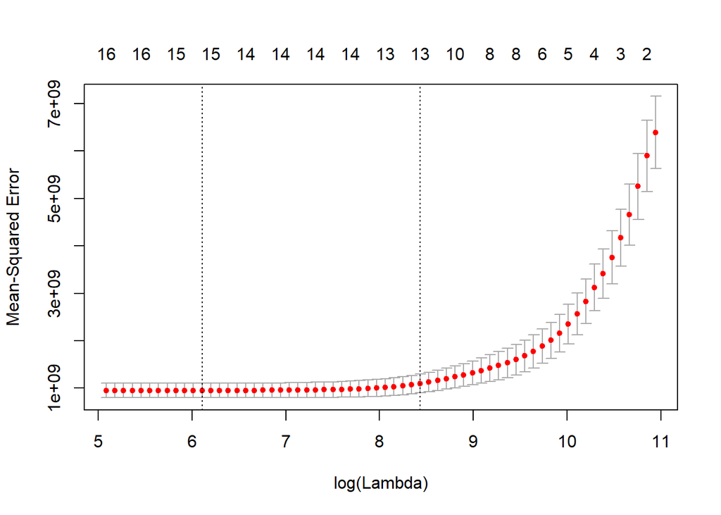

```r
set.seed(705)
cv.out <- cv.glmnet(x[train, ], y[train], alpha = 1)
plot(cv.out)
```

Here we find the best lambda by tuning the model parameters and calculate the RMSE metric which yields a value of 29185.42.This is probably the best RMSE obtained until here.

```r
bestlam <- cv.out$lambda.min
bestlam
```

```
## [1] 449.051
```

```r
lasso.pred <- predict(lasso.mod, s = bestlam, newx = x[test, ])
mean((lasso.pred - y.test)^2)
```

```
## [1] 851788500
```

```r
lasso.RMSE <- sqrt(mean((lasso.pred - y.test)^2))
lasso.RMSE
```

```
## [1] 29185.42
```

Below are the coefficients associated with the best lambda.

```r
out <- glmnet(x, y, alpha = 1, lambda = grid)
lasso.coef <- predict(out, type = "coefficients", s = bestlam)[1:16, ]
lasso.coef
```

```
##          (Intercept)            GrLivArea          TotalBsmtSF
##          180777.2655           29626.7210           13299.7443
##            YearBuilt      Condition2_PosN       OverallQual_10
##           18453.1944           -1663.3511            7297.1572
##         SaleType_New Neighborhood_StoneBr              LotArea
##            6269.2174            6556.7601            6349.1459
## Neighborhood_NridgHt           GarageArea    HouseStyle_1Story
##            6610.9188            9074.7990            -357.6567
## Neighborhood_Crawfor       KitchenQual_Ex Neighborhood_NoRidge
##            6702.7445           11368.6123            6710.4052
##         Fireplaces_2
##            3135.0559
```

# 6 Principal Components Regression

PCR is similar to PCA.We can use the PCR model to predict the Sale Price.PCR creates a series of principle components and calculates the CV score for each. The score will be visualized in the validation plot that follows.

```r
set.seed(705)
pcr.fit <- pcr(SalePrice ~ ., data = Trfeatures, validation = "CV")
summary(pcr.fit)
```

```
## Data:    X dimension: 1456 16
##  Y dimension: 1456 1
## Fit method: svdpc
## Number of components considered: 16
##
## VALIDATION: RMSEP
## Cross-validated using 10 random segments.
##        (Intercept)  1 comps  2 comps  3 comps  4 comps  5 comps  6 comps
## CV           76723    76735    36651    32087    31793    31928    31394
## adjCV        76723    76730    36515    31957    32024    32030    31313
##        7 comps  8 comps  9 comps  10 comps  11 comps  12 comps  13 comps
## CV       31412    31283    31083     31096     31058     31016     31065
## adjCV    31446    31173    31053     31066     31049     30970     31029
##        14 comps  15 comps   16 comps
## CV        30927     30229  1.594e+19
## adjCV     30974     30208  1.512e+19
##
## TRAINING: % variance explained
##             1 comps  2 comps  3 comps  4 comps  5 comps  6 comps  7 comps
## X          99.99152    99.99    99.99   100.00   100.00    100.0   100.00
## SalePrice   0.07542    76.73    81.94    82.57    82.88     83.7    83.87
##            8 comps  9 comps  10 comps  11 comps  12 comps  13 comps
## X           100.00   100.00    100.00    100.00    100.00    100.00
## SalePrice    84.21    84.25     84.28     84.29     84.41     84.41
##            14 comps  15 comps  16 comps
## X            100.00    100.00    100.00
## SalePrice     84.45     85.35     85.67
```

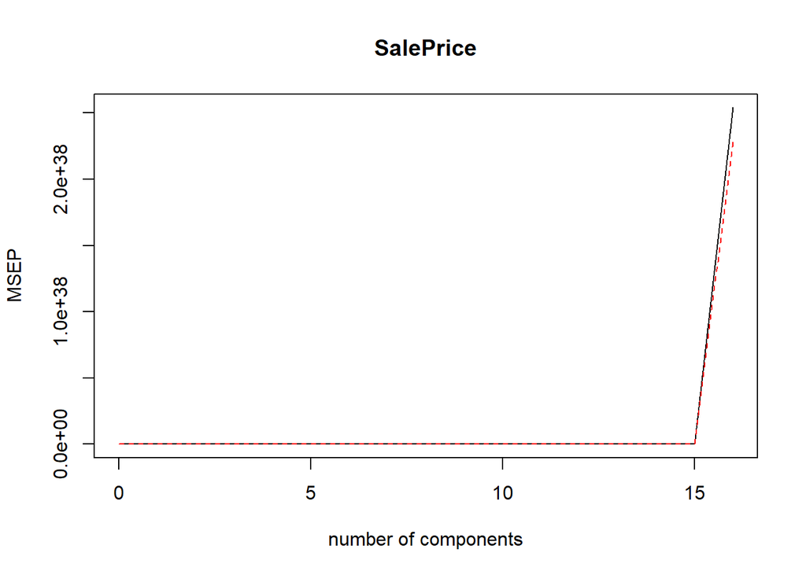

```r
validationplot(pcr.fit, val.type = "MSEP")
```

The PCR yields a RMSE OF 29366.41

```r
pcr.fit <- pcr(SalePrice ~ ., data = Trfeatures, subset = train, validation = "CV")
pcr.pred <- predict(pcr.fit, x[test, ], ncomp = 16)
mean((pcr.pred - y.test)^2)
```

```
## [1] 862386213
```

```r
pcr.RMSE <- sqrt(mean((pcr.pred - y.test)^2))
pcr.RMSE
```

```
## [1] 29366.41
```

```r
pcr.fit <- pcr(y ~ x, ncomp = 16)
summary(pcr.fit)
```

```
## Data:    X dimension: 1456 16
##  Y dimension: 1456 1
## Fit method: svdpc
## Number of components considered: 16
## TRAINING: % variance explained
##     1 comps  2 comps  3 comps  4 comps  5 comps  6 comps  7 comps  8 comps
## X  99.99152    99.99    99.99   100.00   100.00    100.0   100.00   100.00
## y   0.07542    76.73    81.94    82.57    82.88     83.7    83.87    84.21
##    9 comps  10 comps  11 comps  12 comps  13 comps  14 comps  15 comps
## X   100.00    100.00    100.00    100.00    100.00    100.00    100.00
## y    84.25     84.28     84.29     84.41     84.41     84.45     85.35
##    16 comps
## X    100.00
## y     85.67
```

# 7 Decision Tree

Here we calculate the median of the Sales Price to build a decision tree.Here the model chooses only 9 important features.

```r
AmesDT <- TrDumwTg
median(AmesDT$SalePrice)
```

```
## [1] 163000
```

```r
High <- ifelse(AmesDT$SalePrice < 162999, "No", "Yes")
AmesDT <- data.frame(AmesDT, High)
tree.AmesDT <- tree::tree(High ~ . - SalePrice, AmesDT)
summary(tree.AmesDT)
```

```
##
## Classification tree:
## tree::tree(formula = High ~ . - SalePrice, data = AmesDT)
## Variables actually used in tree construction:
## [1] "YearBuilt"     "GrLivArea"     "LotArea"       "TotalBsmtSF"
## [5] "BsmtFinSF1"    "OverallQual_5" "YearRemodAdd"  "LotFrontage"
## [9] "X1stFlrSF"
## Number of terminal nodes:  13
## Residual mean deviance:  0.4217 = 608.5 / 1443
## Misclassification error rate: 0.09203 = 134 / 1456
```

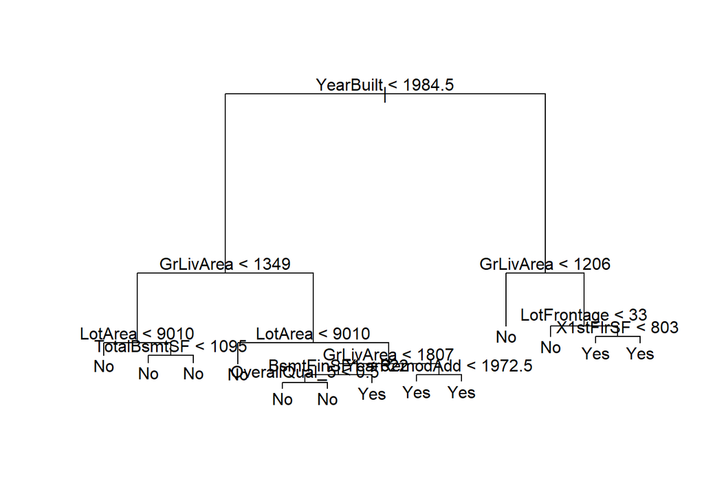

```r
plot(tree.AmesDT)
text(tree.AmesDT, pretty = 0)
```

```r
tree.AmesDT
```

```
## node), split, n, deviance, yval, (yprob)
##       * denotes terminal node
##
##  1) root 1456 2018.00 Yes ( 0.499313 0.500687 )
##    2) YearBuilt < 1984.5 882  981.90 No ( 0.755102 0.244898 )
##      4) GrLivArea < 1349 490  185.60 No ( 0.953061 0.046939 )
##        8) LotArea < 9010 299    0.00 No ( 1.000000 0.000000 ) *
##        9) LotArea > 9010 191  140.50 No ( 0.879581 0.120419 )
##         18) TotalBsmtSF < 1095 139   49.45 No ( 0.956835 0.043165 ) *
##         19) TotalBsmtSF > 1095 52   65.73 No ( 0.673077 0.326923 ) *
##      5) GrLivArea > 1349 392  543.30 No ( 0.507653 0.492347 )
##       10) LotArea < 9010 118  107.40 No ( 0.830508 0.169492 ) *
##       11) LotArea > 9010 274  360.70 Yes ( 0.368613 0.631387 )
##         22) GrLivArea < 1807 163  225.80 No ( 0.515337 0.484663 )
##           44) BsmtFinSF1 < 622 109  139.70 No ( 0.660550 0.339450 )
##             88) OverallQual_5 < 0.5 71   98.30 No ( 0.521127 0.478873 ) *
##             89) OverallQual_5 > 0.5 38   20.99 No ( 0.921053 0.078947 ) *
##           45) BsmtFinSF1 > 622 54   57.21 Yes ( 0.222222 0.777778 ) *
##         23) GrLivArea > 1807 111   95.05 Yes ( 0.153153 0.846847 )
##           46) YearRemodAdd < 1972.5 41   53.85 Yes ( 0.365854 0.634146 ) *
##           47) YearRemodAdd > 1972.5 70   18.16 Yes ( 0.028571 0.971429 ) *
##    3) YearBuilt > 1984.5 574  388.80 Yes ( 0.106272 0.893728 )
##      6) GrLivArea < 1206 53   48.29 No ( 0.830189 0.169811 ) *
##      7) GrLivArea > 1206 521  149.80 Yes ( 0.032630 0.967370 )
##       14) LotFrontage < 33 15   20.73 No ( 0.533333 0.466667 ) *
##       15) LotFrontage > 33 506   90.37 Yes ( 0.017787 0.982213 )
##         30) X1stFlrSF < 803 58   42.72 Yes ( 0.120690 0.879310 ) *
##         31) X1stFlrSF > 803 448   25.64 Yes ( 0.004464 0.995536 ) *
```

```r
set.seed(805)
dim(AmesDT)
```

```
## [1] 1456  314
```

```r
train <- sample(1:nrow(AmesDT), 728)
Ames.test <- AmesDT[-train, ]
High.test <- High[-train]
tree.Ames <- tree(High ~ . - SalePrice, AmesDT, subset = train)
tree.pred <- predict(tree.Ames, Ames.test, type = "class")
table(tree.pred, High.test)
```

```
##          High.test
## tree.pred  No Yes
##       No  315  41
##       Yes  42 330
```

```r
(315 + 330)/728
```

```
## [1] 0.885989
```

```r
set.seed(805)
cv.Ames <- cv.tree(tree.AmesDT, FUN = prune.misclass)
names(cv.Ames)
```

```
## [1] "size"   "dev"    "k"      "method"
```

```r
cv.Ames
```

```
## $size
## [1] 13  8  7  5  4  2  1
##
## $dev
## [1] 174 174 174 183 272 275 770
##
## $k
## [1]  -Inf   0.0   1.0  17.5  35.0  36.0 450.0
##
## $method
## [1] "misclass"
##
## attr(,"class")
## [1] "prune"         "tree.sequence"
```

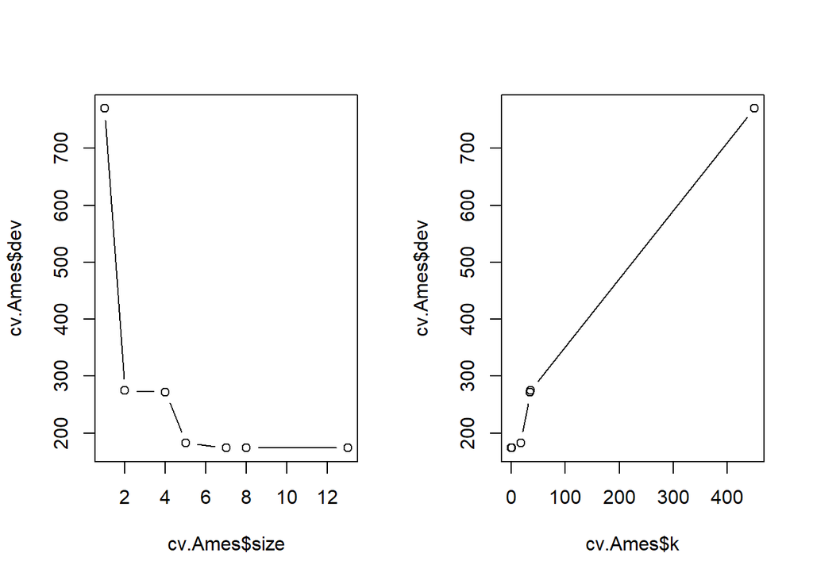

```r
par(mfrow = c(1, 2))
plot(cv.Ames$size, cv.Ames$dev, type = "b")
plot(cv.Ames$k, cv.Ames$dev, type = "b")
```

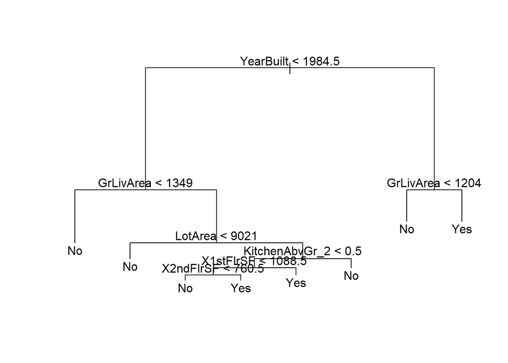

```r
prune.Ames <- prune.misclass(tree.Ames, best = 7)
plot(prune.Ames)
text(prune.Ames, pretty = 0)
```

```r
tree.pred <- predict(prune.Ames, Ames.test, type = "class")
table(tree.pred, High.test)
```

[output not shown]

```r
(311 + 338)/728
```

```
## [1] 0.8914835
```

# 8 Random Forest Analysis(with Bagging)

The Random Forest with Bagging generates 500 decision trees and averages the results.It achieves an adjusted R2 of 85.7.

```r
set.seed(805)
Ames.Bag <- randomForest(SalePrice ~ ., data = AmesDT, subset = train, mtry = 18,
    importance = TRUE)
Ames.Bag
```

```
##
## Call:
##  randomForest(formula = SalePrice ~ ., data = AmesDT, mtry = 18,      importance = TRUE, subset = train)
##                Type of random forest: regression
##                      Number of trees: 500
## No. of variables tried at each split: 18
##
##           Mean of squared residuals: 829972424
##                     % Var explained: 85.7
```

We calculate an RMSE of 28664.The RMSE is better than the Ridge and Lasso regression.

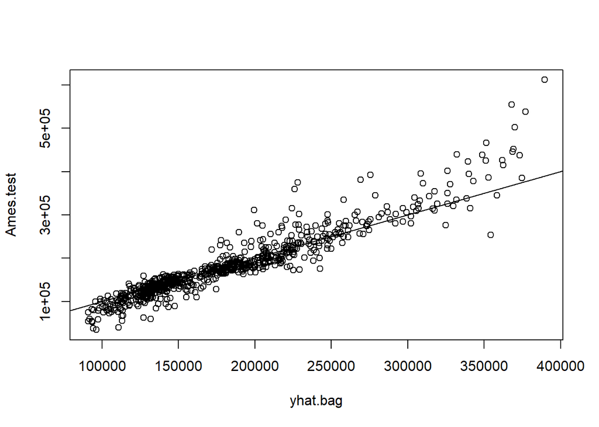

```r
yhat.bag <- predict(Ames.Bag, newdata = AmesDT[-train, ])
Ames.test <- AmesDT[-train, "SalePrice"]
plot(yhat.bag, Ames.test)
abline(0, 1)
```

```r
mean((yhat.bag - Ames.test)^2)
```

```
## [1] 821668279
```

```r
bag.RMSE <- sqrt(mean((yhat.bag - Ames.test)^2))
bag.RMSE
```

```
## [1] 28664.76
```

# 9 Support Vector Machine

```r
svm.mod <- svm(SalePrice ~ ., data = Trfeatures)
svm.pred <- predict(svm.mod, lm.test)
svm.mod
```

```
##
## Call:
## svm(formula = SalePrice ~ ., data = Trfeatures)
##
##
## Parameters:
##    SVM-Type:  eps-regression
##  SVM-Kernel:  radial
##        cost:  1
##       gamma:  0.0625
##     epsilon:  0.1
##
##
## Number of Support Vectors:  1011
```

```r
mean((svm.pred - Ames.test)^2)
```

```
## [1] 9527359055
```

```r
svm.RMSE <- sqrt(mean((svm.pred - Ames.test)^2))
svm.RMSE
```

```
## [1] 97608.19
```

Of all the algorithms applied on the Ames Data set Ridge,Lasso,PCR,Random Forest Bagging perform better compared to SVM and others.